# DATA 606 - Lab 5B - Confidence Levels

Preston Peck

2021-10-15

# Confidence Levels

https://htmlpreview.github.io/?https://github.com/jbryer/DATA606/blob/master/inst/labs/Lab5b/Lab5b_confidence_intervals.html

```r
library(tidyverse)
library(openintro)
library(infer)
library(psych)
library(oilabs)
```

```r
set.seed(37)

nLabel <- "n"
yesLabel <- "Yes"
noLabel <- "No"

us_adults <- tibble(
  climate_change_affects = c(rep(yesLabel, 62000), rep(noLabel, 38000))
)
```

### Exercise 1

```r
sizeSample <- function(sample, size = NULL) {
  sizedSample <- if(is.null(size)) {
    sample
  } else {
    sample %>%
      sample_n(size)
  }

  return(sizedSample)
}
```

```r
analyzeSamplingProportion <- function(sample, size = NULL) {
  sizedSample <- sizeSample(sample, size)

  sizedSampleProportions <- sizedSample %>%
    count(climate_change_affects) %>%
    mutate(p = n / sum(n)) %>%
    select(climate_change_affects, n, p)

  print(sizedSampleProportions)

  print(ggplot(sizedSample, aes(x = climate_change_affects)) +
    geom_bar() +
    labs(
      x = "",
      y = "",
      title = "Do you think climate change is affecting your local community?"
    ) +
    coord_flip())

  return(sizedSampleProportions)
}
```

```r
numOfElements = 60



us_adultsProportions <- us_adults %>%
  analyzeSamplingProportion
```

```
## # A tibble: 2 × 3
##   climate_change_affects     n     p
##   <chr>                  <int> <dbl>
## 1 No                     38000  0.38
## 2 Yes                    62000  0.62
```

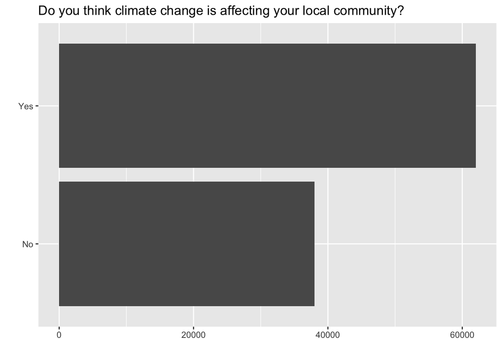

```r
samp <- us_adults %>%
  sizeSample(numOfElements)

sampProportions <- samp %>%
  analyzeSamplingProportion
```

```
## # A tibble: 2 × 3
##   climate_change_affects     n     p
##   <chr>                  <int> <dbl>
## 1 No                        23 0.383
## 2 Yes                       37 0.617
```

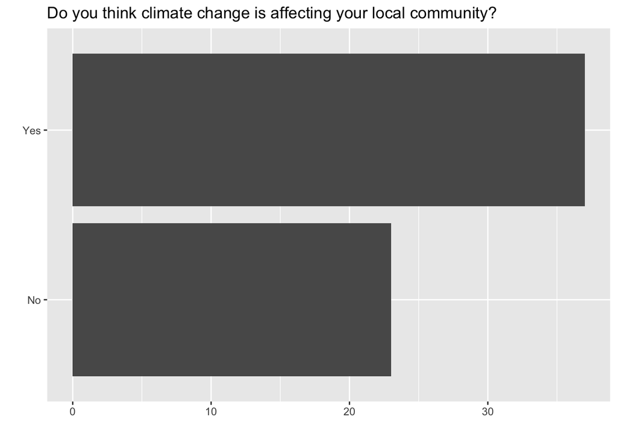

### Exercise 2

With such a small sample size, the proportions will be very prone to changing since small variations can result in big changes, so I can’t say for sure that other students will have the same results, but we will probably have similar results.

### Exercise 3

95% confidence means that 95% of the time across all samplings, the average proportion of the element in question will fall somewhere within the confidence interval

```r
analyzeConfidenceInterval <- function(sample, size = NULL, reps = 1000, yes = TRUE, level = 0.95, print = TRUE) {
  sizedSample <- sizeSample(sample, size)

  interval <- sizedSample %>%
    specify(response = climate_change_affects, success = ifelse (yes, yesLabel, noLabel)) %>%
    generate(reps = reps, type = "bootstrap") %>%
    calculate(stat = "prop") %>%
    get_ci(level = level)

  if (print) {
    print(interval)
    print(c(interval$upper_ci, interval$lower_ci) %>%
            describe)
  }

  return(interval)
}
```

```r
interval60_95 <- samp %>%
  analyzeConfidenceInterval
```

```
## # A tibble: 1 × 2
##   lower_ci upper_ci
##      <dbl>    <dbl>
## 1    0.483    0.733
##    vars n mean   sd median trimmed  mad  min  max range skew kurtosis   se
## X1    1 2 0.61 0.18   0.61    0.61 0.19 0.48 0.73  0.25    0    -2.75 0.12
```

### Exercise 5

As each one of us is 95% confident of our range, the average confidence level among the class is 95%, so 95% of the total intervals we generated should correctly encapsulate the true average

### Exercise 6

```r
emptyTable <- function(cols, rows, colNames = NULL) {
  tibble <- data.frame(matrix(NA, ncol = cols, nrow = rows)) %>%
    as_tibble

  if (!is.null(colNames)) {
    colnames(tibble) <- colNames
  }

  return(tibble)
}
```

```r
lowerCILabel <- "lower_ci"
upperCILabel <- "upper_ci"
cIColNames <- c(lowerCILabel, upperCILabel)



analyzeConfidenceIntervals <- function(sample, size = NULL, reps = 1000, yes = TRUE, level = 0.95, loops = 50, print = FALSE) {
  intervals <- emptyTable(2, loops, cIColNames)

  for (i in 1:loops) {
    intervals[i,] <- sample %>%
      analyzeConfidenceInterval(size, reps, yes, level, print)
  }

  print(intervals)
  print(intervals %>%
          describe)

  return(intervals)
}
```

```r
intervals50_60 <- us_adults %>%
  analyzeConfidenceIntervals(numOfElements)
```

```
## # A tibble: 50 × 2
##    lower_ci upper_ci
##       <dbl>    <dbl>
##  1    0.467    0.7
##  2    0.583    0.8
##  3    0.433    0.683
##  4    0.55     0.783
##  5    0.55     0.783
##  6    0.567    0.8
##  7    0.533    0.767
##  8    0.483    0.733
##  9    0.517    0.75
## 10    0.467    0.7
## # … with 40 more rows
##          vars  n mean   sd median trimmed  mad  min  max range skew kurtosis
## lower_ci    1 50 0.50 0.07   0.49    0.50 0.09 0.35 0.70  0.35 0.47    -0.14
## upper_ci    2 50 0.74 0.06   0.73    0.74 0.07 0.62 0.88  0.27 0.27    -0.49
##            se
## lower_ci 0.01
## upper_ci 0.01
```

```r
numOfElements = 1000



intervals50_1000 <- us_adults %>%
  analyzeConfidenceIntervals(numOfElements)
```

```
## # A tibble: 50 × 2
##    lower_ci upper_ci
##       <dbl>    <dbl>
##  1    0.603    0.663
##  2    0.605    0.665
##  3    0.576    0.636
##  4    0.602    0.662
##  5    0.601    0.662
##  6    0.578    0.638
##  7    0.563    0.623
##  8    0.598    0.655
##  9    0.602    0.663
## 10    0.594    0.653
## # … with 40 more rows
##          vars  n mean   sd median trimmed  mad  min  max range  skew kurtosis
## lower_ci    1 50 0.59 0.01   0.59    0.59 0.02 0.55 0.60  0.05 -0.57    -0.56
## upper_ci    2 50 0.65 0.01   0.65    0.65 0.02 0.61 0.66  0.05 -0.55    -0.58
##          se
## lower_ci  0
## upper_ci  0
```

```r
analyzeConfidenceIntervalAgainstTrue <- function(intervals, true) {
  accuracyProportions <- intervals %>%
    apply(1, function(x) true[[2,3]] > x[1] & true[[2,3]] < x[2]) %>%
    as_tibble %>%
    count(value) %>%
    mutate(p = n / sum(n)) %>%
    select(value, n, p)

  accuracyProportions %>%
    rename_at("value", ~"is_within_range")

  print(accuracyProportions)
  return(accuracyProportions)
}
```

```r
accuracy50_95 <- intervals50_60 %>%
  analyzeConfidenceIntervalAgainstTrue(us_adultsProportions)
```

```
## # A tibble: 2 × 3
##   value     n     p
##   <lgl> <int> <dbl>
## 1 FALSE     4  0.08
## 2 TRUE     46  0.92
```

```r
accuracy50_95 <- intervals50_1000 %>%
  analyzeConfidenceIntervalAgainstTrue(us_adultsProportions)
```

```
## # A tibble: 2 × 3
##   value     n     p
##   <lgl> <int> <dbl>
## 1 FALSE     1  0.02
## 2 TRUE     49  0.98
```

### Exercise 7

In order to be less accurate, the interval would have to shrink and be more specific so that the average is outside of it more often

### Exercise 8

```r
confidence50 <- 0.50



interval50_60 <- samp %>%
  analyzeConfidenceInterval(level = confidence50)
```

```
## # A tibble: 1 × 2
##   lower_ci upper_ci
##      <dbl>    <dbl>
## 1    0.567    0.667
##    vars n mean   sd median trimmed  mad  min  max range skew kurtosis   se
## X1    1 2 0.62 0.07   0.62    0.62 0.07 0.57 0.67   0.1    0    -2.75 0.05
```

### Exercise 9

```r
plotConfidenceIntervals <- function(sample, size = NULL, level, true) {
  intervals <- sample %>%
    analyzeConfidenceIntervals(size = size, level = level)

  accuracy <- intervals %>%
    analyzeConfidenceIntervalAgainstTrue(true)

  accuracies <- intervals %>%
      apply(1, function(x) true[[2,3]] > x[1] & true[[2,3]] < x[2])

  ggplot(intervals, aes(lower_ci, upper_ci, colour = accuracies)) +
    geom_point()

  plot_ci(intervals$lower_ci, intervals$upper_ci, as.numeric(true[[2,3]]))

  return(accuracy)
}
```

```
## # A tibble: 50 × 2
##    lower_ci upper_ci
##       <dbl>    <dbl>
##  1    0.583    0.65
##  2    0.65     0.733
##  3    0.6      0.683
##  4    0.717    0.783
##  5    0.583    0.65
##  6    0.6      0.683
##  7    0.517    0.6
##  8    0.6      0.7
##  9    0.567    0.65
## 10    0.633    0.717
## # … with 40 more rows
##          vars  n mean   sd median trimmed  mad  min  max range  skew kurtosis
## lower_ci    1 50 0.59 0.07   0.58    0.59 0.07 0.45 0.72  0.27 -0.01    -0.80
## upper_ci    2 50 0.67 0.06   0.68    0.68 0.05 0.53 0.78  0.25 -0.16    -0.74
##            se
## lower_ci 0.01
## upper_ci 0.01
## # A tibble: 2 × 3
##   value     n     p
##   <lgl> <int> <dbl>
## 1 FALSE    29  0.58
## 2 TRUE     21  0.42
```

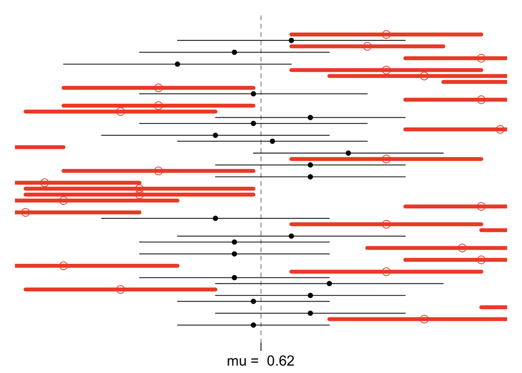

```r
numOfElements <- 60



accuracy50_50 <- us_adults %>%
  plotConfidenceIntervals(numOfElements, confidence50, us_adultsProportions)
```

### Exercise 10

Because the confidence is lower, the range is expected to shrink to exclude the true proportion more often

```
## # A tibble: 50 × 2
##    lower_ci upper_ci
##       <dbl>    <dbl>
##  1    0.583    0.583
##  2    0.7      0.7
##  3    0.633    0.65
##  4    0.576    0.583
##  5    0.667    0.667
##  6    0.7      0.717
##  7    0.583    0.6
##  8    0.583    0.6
##  9    0.567    0.583
## 10    0.6      0.617
## # … with 40 more rows
##          vars  n mean   sd median trimmed  mad  min  max range skew kurtosis
## lower_ci    1 50 0.62 0.06   0.62    0.62 0.07 0.52 0.77  0.25 0.43    -0.49
## upper_ci    2 50 0.63 0.06   0.63    0.63 0.07 0.53 0.78  0.25 0.44    -0.43
##            se
## lower_ci 0.01
## upper_ci 0.01
## # A tibble: 2 × 3
##   value     n     p
##   <lgl> <int> <dbl>
## 1 FALSE    46  0.92
## 2 TRUE      4  0.08
```

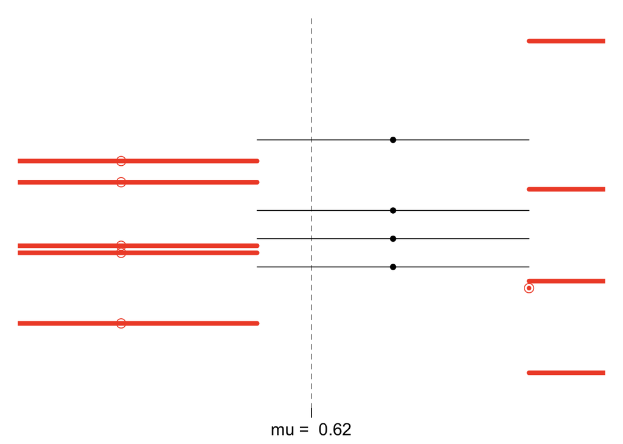

```r
confidence10 <- 0.10



accuracy50_10 <- us_adults %>%
  plotConfidenceIntervals(numOfElements, confidence10, us_adultsProportions)
```

### Exercise 11

The range of intervals decreases as sample size increases

```r
tinyNum <- 2
smallNum <- 10
mediumNum <- 100
largeNum <- 1000
massiveNum <- 10000



interval2_95 <- us_adults %>%
  analyzeConfidenceInterval(tinyNum)
```

```
## # A tibble: 1 × 2
##   lower_ci upper_ci
##      <dbl>    <dbl>
## 1        0        1
##    vars n mean   sd median trimmed  mad min max range skew kurtosis  se
## X1    1 2  0.5 0.71    0.5     0.5 0.74   0   1     1    0    -2.75 0.5
```

```r
interval10_95 <- us_adults %>%
  analyzeConfidenceInterval(smallNum)
```

```
## # A tibble: 1 × 2
##   lower_ci upper_ci
##      <dbl>    <dbl>
## 1      0.5        1
##    vars n mean   sd median trimmed  mad min max range skew kurtosis   se
## X1    1 2 0.75 0.35   0.75    0.75 0.37 0.5   1   0.5    0    -2.75 0.25
```

```r
interval100_95 <- us_adults %>%
  analyzeConfidenceInterval(mediumNum)
```

```
## # A tibble: 1 × 2
##   lower_ci upper_ci
##      <dbl>    <dbl>
## 1     0.54     0.74
##    vars n mean   sd median trimmed  mad  min  max range skew kurtosis  se
## X1    1 2 0.64 0.14   0.64    0.64 0.15 0.54 0.74   0.2    0    -2.75 0.1
```

```r
interval1000_95 <- us_adults %>%
  analyzeConfidenceInterval(largeNum)
```

```
## # A tibble: 1 × 2
##   lower_ci upper_ci
##      <dbl>    <dbl>
## 1    0.590    0.652
##    vars n mean   sd median trimmed  mad  min  max range skew kurtosis   se
## X1    1 2 0.62 0.04   0.62    0.62 0.05 0.59 0.65  0.06    0    -2.75 0.03
```

```r
interval10000_95 <- us_adults %>%
  analyzeConfidenceInterval(massiveNum)
```

```
## # A tibble: 1 × 2
##   lower_ci upper_ci
##      <dbl>    <dbl>
## 1    0.606    0.625
##    vars n mean   sd median trimmed  mad  min  max range skew kurtosis   se
## X1    1 2 0.62 0.01   0.62    0.62 0.01 0.61 0.62  0.02    0    -2.75 0.01
```

### Exercise 12

The range of intervals stays fairly consistent as bootstrap samples increase, and because of this, standard error will also stays fairly consistent

```r
interval2_95 <- us_adults %>%
  analyzeConfidenceInterval(numOfElements, reps = tinyNum)
```

```
## # A tibble: 1 × 2
##   lower_ci upper_ci
##      <dbl>    <dbl>
## 1    0.533    0.533
##    vars n mean sd median trimmed mad  min  max range skew kurtosis se
## X1    1 2 0.53  0   0.53    0.53   0 0.53 0.53     0  NaN      NaN  0
```

```r
interval10_95 <- us_adults %>%
  analyzeConfidenceInterval(numOfElements, reps = smallNum)
```

```
## # A tibble: 1 × 2
##   lower_ci upper_ci
##      <dbl>    <dbl>
## 1    0.532    0.739
##    vars n mean   sd median trimmed  mad  min  max range skew kurtosis  se
## X1    1 2 0.64 0.15   0.64    0.64 0.15 0.53 0.74  0.21    0    -2.75 0.1
```

```r
interval100_95 <- us_adults %>%
  analyzeConfidenceInterval(numOfElements, reps = mediumNum)
```

```
## # A tibble: 1 × 2
##   lower_ci upper_ci
##      <dbl>    <dbl>
## 1      0.5    0.767
##    vars n mean   sd median trimmed mad min  max range skew kurtosis   se
## X1    1 2 0.63 0.19   0.63    0.63 0.2 0.5 0.77  0.27    0    -2.75 0.13
```

```r
interval1000_95 <- us_adults %>%
  analyzeConfidenceInterval(numOfElements, reps = largeNum)
```

```
## # A tibble: 1 × 2
##   lower_ci upper_ci
##      <dbl>    <dbl>
## 1     0.45    0.717
##    vars n mean   sd median trimmed mad  min  max range skew kurtosis   se
## X1    1 2 0.58 0.19   0.58    0.58 0.2 0.45 0.72  0.27    0    -2.75 0.13
```

```r
interval10000_95 <- us_adults %>%
  analyzeConfidenceInterval(numOfElements, reps = massiveNum)
```

```
## # A tibble: 1 × 2
##   lower_ci upper_ci
##      <dbl>    <dbl>
## 1    0.383     0.65
##    vars n mean   sd median trimmed mad  min  max range skew kurtosis   se
## X1    1 2 0.52 0.19   0.52    0.52 0.2 0.38 0.65  0.27    0    -2.75 0.13
```